# Saunders Package Function Demonstrations

Find the package at github.com/jamesbeeson01/Saunders

Install the Saunders package with `devtools::install_github("jamesbeeson01/Saunders")` and load it with `library(Saunders)`. Has ggplot and dplyr dependencies

```r
#devtools::install_github("jamesbeeson01/Saunders")
library(tidyverse)
library(Saunders)
```

# geom_fit()

This function uses predict() to create any line from any linear model, even high dimensional models with y transformations. It is meant to imitate geom_smooth in that it creates a line with a confidence interval, but it can also use a prediction interval if specified.

It assumes the first variable in the lm (i.e. $\beta_1$) is the x axis. This is a potential place to improve the function. It also does not infer any additional variables if they are not provided, and does not change values dynamically (like with facet_wrap or group)

- `model` A linear model (lm()) to create a line from using predict(). The function attempts to automatically extract the primary predictor (x) variable from the model object.
- `newdata` An optional data frame containing values for other predictor variables in the model (if any) to be held constant during prediction. If `NA` (default), predictions are made only based on the primary predictor sequence. Note: The current internal implementation uses `cbind`, ensure `newdata` is structured appropriately (e.g., a single row data frame with the constant values).
- `resolution` An integer specifying the number of points across the range of the primary predictor (x) at which to evaluate the model. Default is 500.
- `color` A character string specifying the color for the resultant line and ribbon. Default is “blue”.
- `interval` A character string specifying the type of interval required: “confidence” (default) or “prediction”. Passed to `predict()`.
- `trans` A function to transform the predicted values and interval bounds (e.g., `exp` for log-transformed response models). Default is `identity` (no transformation).
- `se` Removes confidence band if specified FALSE (similar to geom_smooth). Defaults to TRUE

#### Y Transformations

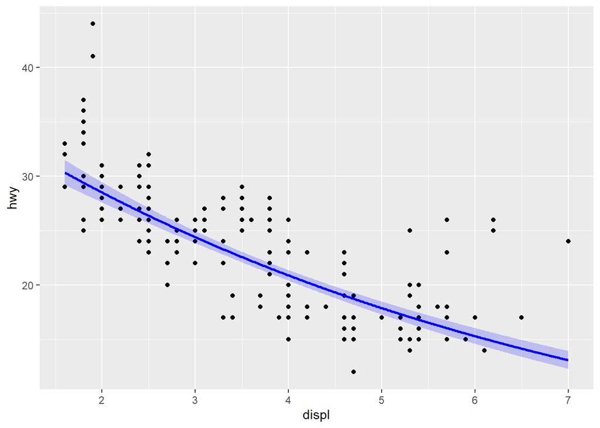

```r
lm.log <- lm(log(hwy) ~ displ, data = mpg)

ggplot(mpg, aes(x = displ, y = hwy)) +
  geom_point() +
  geom_fit(lm.log, trans = exp)
```

#### Prediction Interval

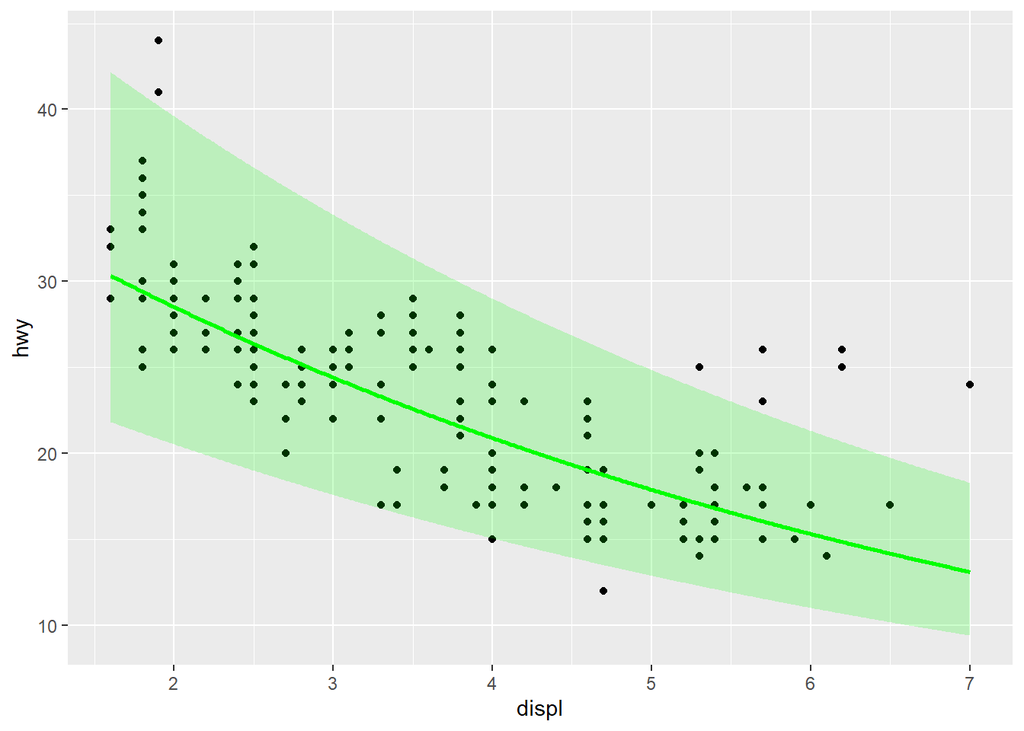

```r
ggplot(mpg, aes(x = displ, y = hwy)) +
  geom_point() +
  geom_fit(lm.log, trans = exp, interval = "prediction", color = "green")
```

#### Complex X Functions

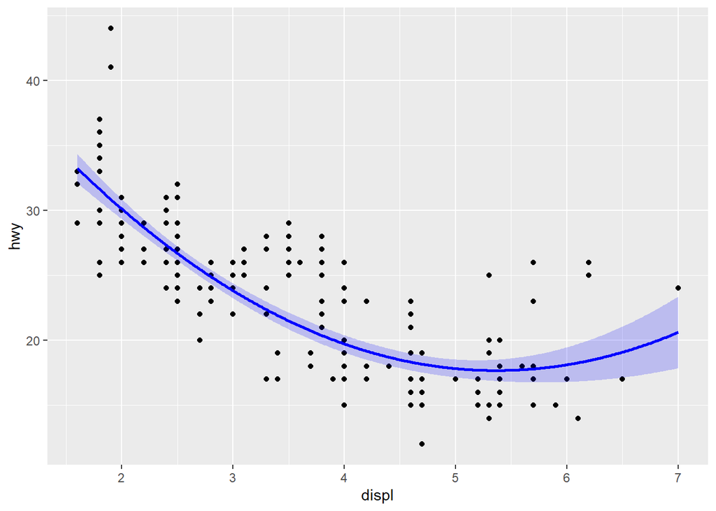

```r
lm.displ2 <- lm(hwy ~ displ + I(displ^2), mpg)

ggplot(mpg, aes(displ, hwy)) +
  geom_point() +
  geom_fit(lm.displ2)
```

#### Additional Variables

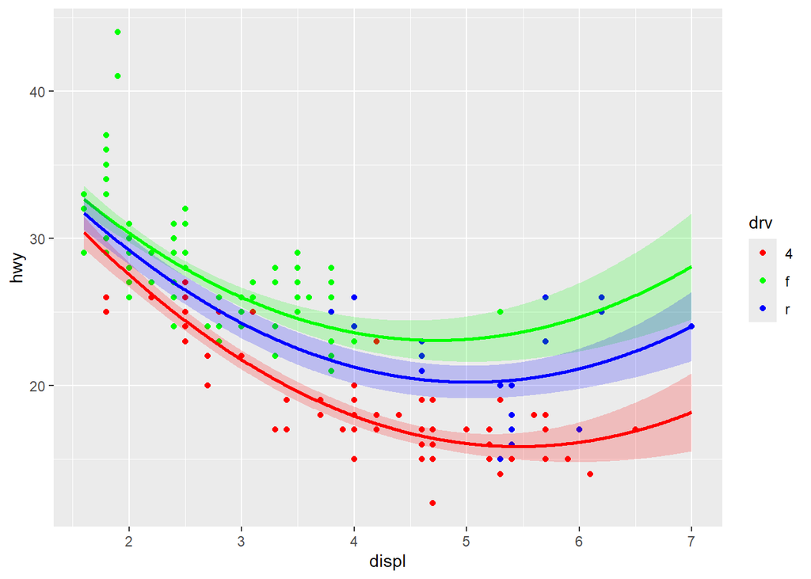

```r
lm.drv <- lm(hwy ~ displ + I(displ^2) + displ:drv, mpg)

ggplot(mpg, aes(displ, hwy, color = drv)) +
  geom_point() +
  geom_fit(lm.drv, data.frame(drv = "4"), color = "red") +
  geom_fit(lm.drv, data.frame(drv = "f"), color = "green") +
  geom_fit(lm.drv, data.frame(drv = "r"), color = "blue") +
  scale_color_manual(values = c("red", "green", "blue"))
```

#### se = FALSE

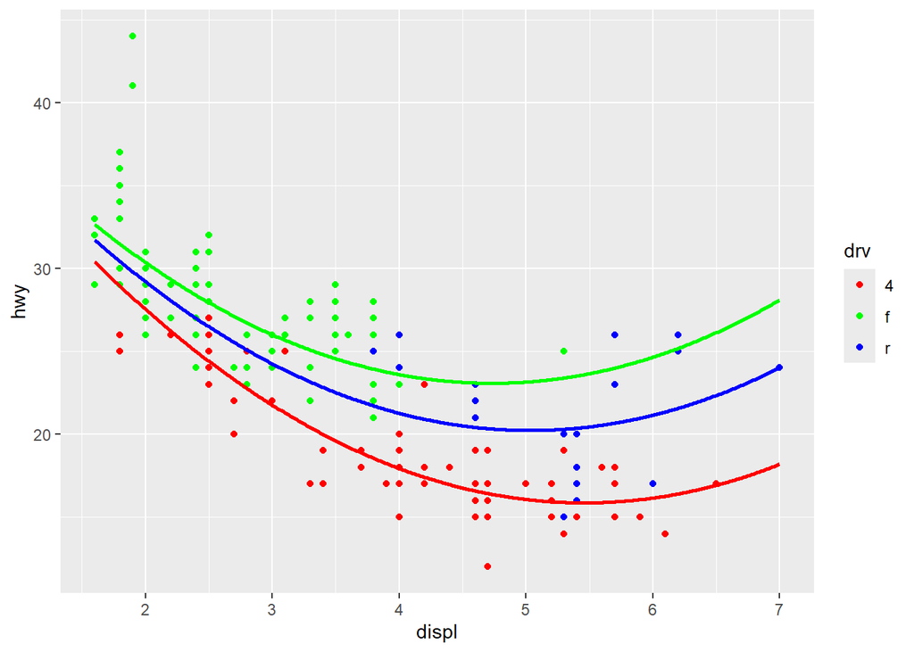

```r
ggplot(mpg, aes(displ, hwy, color = drv)) +
  geom_point() +
  geom_fit(lm.drv, data.frame(drv = "4"), color = "red", se = FALSE) +
  geom_fit(lm.drv, data.frame(drv = "f"), color = "green", se = FALSE) +
  geom_fit(lm.drv, data.frame(drv = "r"), color = "blue", se = FALSE) +
  scale_color_manual(values = c("red", "green", "blue"))
```